# InClass05_data_cleaning_ptt_lubridate

Jilung Hsieh

9/22/2019

# 1 Practice Notes

- Goals: lubridate, stringr, ggplot2, plotting timeline
- Related:
- Unknown: Crawler designs

# 2 Questions

# 3 Loading packages

```r
library(lubridate)  # for processing time
library(tidyverse)
options(stringsAsFactors = F)
```

# 4 Loading data

```r
load("data/HatePolitics_韓_201906010320_raw.rda")
```

# 5 Related sources

- [The lubridate packages document](https://rdrr.io/cran/lubridate/man/lubridate-package.html)
- [Usage: [Stackoverflow] dplyr, lubridate : how to aggregate a dataframe by week?](https://stackoverflow.com/questions/40554231/dplyr-lubridate-how-to-aggregate-a-dataframe-by-week)
- [lubridate cheatsheets](https://evoldyn.gitlab.io/evomics-2018/ref-sheets/R_lubridate.pdf)

# 6 Parsing character to POSIXct R data time object

## 6.1 By base packages

- Using `?strptime` to find formatter
- %a: bbreviated weekday name
- %b: Abbreviated month nam
- %e: Day of the month as decimal number (1–31)
- %X: Time. Locale-specific on output, “%H:%M:%S” on input.
- %Y: Year with century

```r
# Given a character timestamp
t <- "Fri Apr 12 09:12:40 2019"

# Converting t to POSIXlt by strptime()
strptime(t, "%a %b %e %X %Y")
```

```
## [1] "2019-04-12 09:12:40 CST"
```

```r
strptime(t, "%a %b %e %X %Y") %>% class
```

```
## [1] "POSIXlt" "POSIXt"
```

```r
# Converting t to POSIXlt to POSIXct by strptime() and as.POSIXct()
as.POSIXct(strptime(t, "%a %b %e %X %Y")) %>% class
```

```
## [1] "POSIXct" "POSIXt"
```

## 6.2 By lubridate packages

- a: Abbreviated weekday name in the current locale
- b!: Abbreviated or full month name in the current locale.
- d!: Day of the month as decimal number (01–31 or 0–31)
- H: HOUR
- M: MINUTE
- S: SECOND
- Y!: Year with century

```r
# Converting the character time to datetime by lubridate::parse_date_time()
parse_date_time("Fri Apr 12 09:12:40 2019", "ab!d!HMSY!")
```

```
## [1] "2019-04-12 09:12:40 UTC"
```

## 6.3 Time zone

- CST - Central Standard Time (UTC+8)
- UTC - Coordinated Universal Time
- GMT

```r
# Parsing datetime with time zone
parse_date_time("Fri Apr 12 09:12:40 2019", "ab!d!HMSY!", tz = "Asia/Taipei")
```

```
## [1] "2019-04-12 09:12:40 CST"
```

```r
parse_date_time("Fri Apr 12 09:12:40 2019", "ab!d!HMSY!", tz = "America/New_York")
```

```
## [1] "2019-04-12 09:12:40 EDT"
```

# 7 Cleaning posts

- Using `parse_date_time()` to convert time character to POSIXct
- Using `drop_na()` to drop rows having NA in specific columns
- Using `filter()` to filter posts between 2019-01-001 and 2019-06-01
- Using `str_extract()` to extract poster id, or using `str_replace()`

```r
posts <- allp.df %>%
    mutate(ptime = parse_date_time(ptime, "ab!d!HMSY!", tz = "Asia/Taipei")) %>%
    # mutate(ptime = as.POSIXct(strptime(ptime, "%a %b %e %X %Y"))) %>%
    drop_na(ptime, board) %>%
    filter(ptime > as.Date("2018-12-31") & ptime < as.Date("2019-06-01")) %>%
    mutate(poster = str_extract(poster, "[a-zA-Z0-9]+"))%>%
    # mutate(poster = str_replace(poster, "(.+?) \\(.*\\)", "\\1")) %>%
    select(-ip.len)
```

## 7.1 Testing

```r
str_extract("sunyeah ( 湯元嗎)", "\\(.+\\)")
```

```
## [1] "( 湯元嗎)"
```

```r
str_extract
```

```
## function (string, pattern)
## {
##     switch(type(pattern), empty = stri_extract_first_boundaries(string,
##         pattern, opts_brkiter = opts(pattern)), bound = stri_extract_first_boundaries(string,
##         pattern, opts_brkiter = opts(pattern)), fixed = stri_extract_first_fixed(string,
##         pattern, opts_fixed = opts(pattern)), coll = stri_extract_first_coll(string,
##         pattern, opts_collator = opts(pattern)), regex = stri_extract_first_regex(string,
##         pattern, opts_regex = opts(pattern)))
## }
## <bytecode: 0x7ffb7b15aaf8>
## <environment: namespace:stringr>
```

# 8 Plotting

## 8.1 (Deprecated-old-style) by cut()

- `cut()` will turn datetime to factor for the new variable week

```
posts %>%
    mutate(week = cut(ptime, breaks = "week")) %>% glimpse()
    count(week) %>%
    ggplot() + aes(week, n) +
    geom_col() +
    geom_vline(aes(xintercept = as_datetime("2019-02-02")), color="red", alpha=0.5)
```

## 8.2 as_datetime() level

- `geom_vline()` axis must be equivalent with x-axis

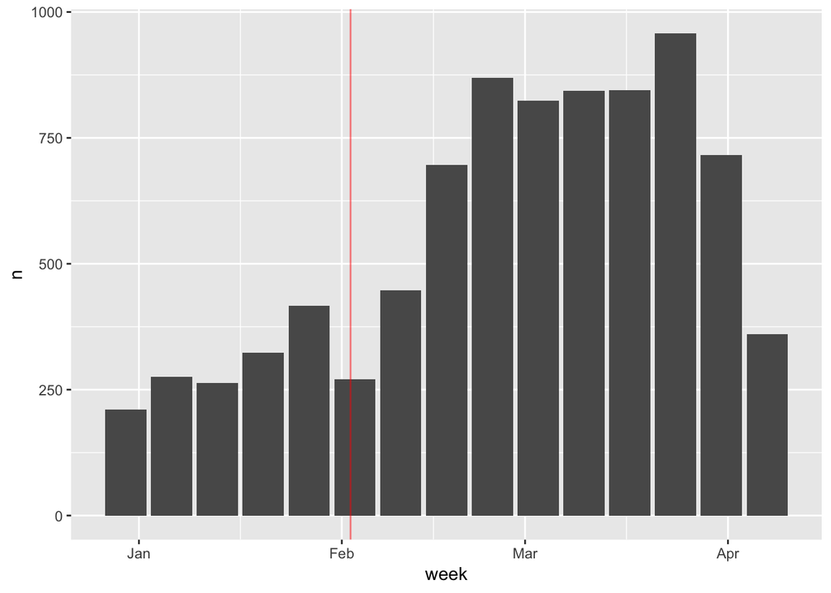

```r
posts %>%
    mutate(week = floor_date(ptime, unit = "weeks")) %>%
    count(week) %>%
    ggplot() + aes(week, n) +
    geom_col() +
    geom_vline(aes(xintercept = as_datetime("2019-02-02")), color="red", alpha=0.5)
```

## 8.3 as_date() level

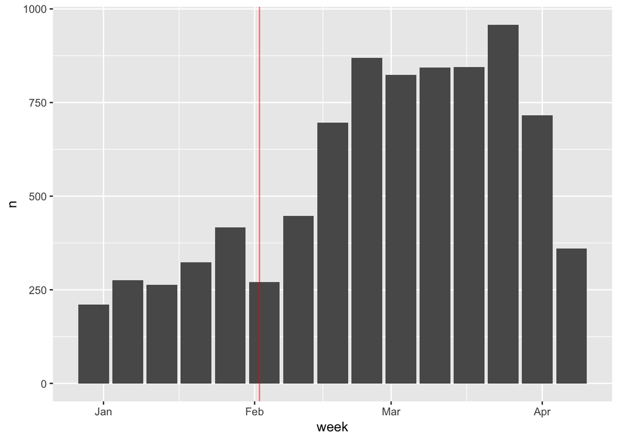

```r
posts %>%
    mutate(week = floor_date(ptime, unit = "weeks") %>% as_date()) %>%
    count(week) %>%
    ggplot() + aes(week, n) +
    geom_col() +
    geom_vline(aes(xintercept = as_date("2019-02-02")), color="red", alpha=0.5)
```

## 8.4 Color specific weeks

- `mutate()` one variable group as bar chart filling group
- Using `if_else()` to create binary choice of colors

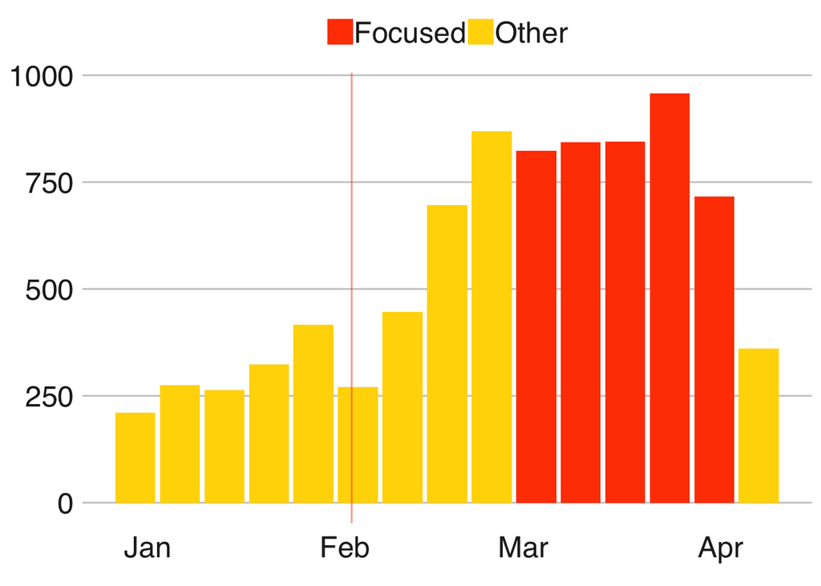

```r
posts %>%
    mutate(week = floor_date(ptime, unit = "weeks") %>% as_date()) %>%
    count(week) %>%
    mutate(group = if_else(week > as.Date("2019-03-02") &
                               week < as.Date("2019-04-02"),
                           "Focused", "Other")) %>%
    ggplot() + aes(week, n, fill = group) +
    geom_col() +
    scale_fill_manual(values = c("Focused" = "OrangeRed", "Other" = "Gold")) +
    geom_vline(aes(xintercept = as_date("2019-02-02")), color="OrangeRed", alpha=0.5) +
    bbplot::bbc_style()
```

# 9 Cleaning comments

```r
comments <- allc.df %>%
    right_join(posts %>% select(plink, poster), by="plink") %>%
    select(-cindex, -ctotal)
```

# 10 Saving posts and comments to an rda with date time

```r
format(now(), "%Y%m%d_%H%M")
```

```
## [1] "20191013_0118"
```

```r
library(stringr)
str_c("Testing_", format(now(), "%Y%m%d_%H%M"), "Testing2")
```

```
## [1] "Testing_20191013_0118Testing2"
```

```r
save(posts, comments,
     file ="data/HatePolitics_Hang_20190101_2019_06_01.rda")
```